# Conditional Autoencoder for Asset Pricing - Part 1: The Data

```python
from pathlib import Path

import numpy as np
import pandas as pd

from statsmodels.regression.rolling import RollingOLS
import statsmodels.api as sm
import matplotlib.pyplot as plt
import seaborn as sns
```

```python
idx = pd.IndexSlice
sns.set_style('whitegrid')
```

```python
results_path = Path('results', 'asset_pricing')
if not results_path.exists():
    results_path.mkdir(parents=True)
```

## Load Data

### Prices

```python
prices = pd.read_hdf(results_path / 'data.h5', 'stocks/prices/adjusted')
```

```python
prices.info(show_counts=True)
```

```
<class 'pandas.core.frame.DataFrame'>
MultiIndex: 17661451 entries, ('A', Timestamp('1999-11-18 00:00:00')) to ('ZYXI', Timestamp('2019-12-31 00:00:00'))
Data columns (total 5 columns):
 #   Column  Non-Null Count     Dtype
---  ------  --------------     -----
 0   close   17661451 non-null  float64
 1   high    17661451 non-null  float64
 2   low     17661451 non-null  float64
 3   open    17661451 non-null  float64
 4   volume  17661451 non-null  float64
dtypes: float64(5)
memory usage: 742.0+ MB
```

### Metadata

```python
metadata = pd.read_hdf(results_path / 'data.h5', 'stocks/info').rename(columns=str.lower)
```

```python
metadata.info()
```

```
<class 'pandas.core.frame.DataFrame'>
Index: 6262 entries, A to ZYXI
Columns: 109 entries, zip to impliedsharesoutstanding
dtypes: bool(2), float64(75), int64(3), object(29)
memory usage: 5.2+ MB
```

### Select tickers with metadata

```python
sectors = (metadata.sector.value_counts() > 50).index
```

```python
tickers_with_errors = ['FTAI', 'AIRT', 'CYBR', 'KTB']
```

```python
tickers_with_metadata = metadata[metadata.sector.isin(sectors) &
                                 metadata.marketcap.notnull() &
                                 metadata.sharesoutstanding.notnull() &
                                (metadata.sharesoutstanding > 0)].index.drop(tickers_with_errors)
```

```python
metadata = metadata.loc[tickers_with_metadata, ['sector', 'sharesoutstanding', 'marketcap']]
metadata.index.name = 'ticker'
```

```python
prices = prices.loc[idx[tickers_with_metadata, :], :]
```

```python
prices.info(null_counts=True)
```

```
<class 'pandas.core.frame.DataFrame'>
MultiIndex: 17312229 entries, ('A', Timestamp('1999-11-18 00:00:00')) to ('ZYXI', Timestamp('2019-12-31 00:00:00'))
Data columns (total 5 columns):
 #   Column  Non-Null Count     Dtype
---  ------  --------------     -----
 0   close   17312229 non-null  float64
 1   high    17312229 non-null  float64
 2   low     17312229 non-null  float64
 3   open    17312229 non-null  float64
 4   volume  17312229 non-null  float64
dtypes: float64(5)
memory usage: 727.4+ MB
```

```python
metadata.info()
```

```
<class 'pandas.core.frame.DataFrame'>
Index: 5749 entries, A to ZYXI
Data columns (total 3 columns):
 #   Column             Non-Null Count  Dtype
---  ------             --------------  -----
 0   sector             5749 non-null   object
 1   sharesoutstanding  5749 non-null   float64
 2   marketcap          5749 non-null   float64
dtypes: float64(2), object(1)
memory usage: 179.7+ KB
```

```python
close = prices.close.unstack('ticker').sort_index()
close.info()
```

```
<class 'pandas.core.frame.DataFrame'>
DatetimeIndex: 7559 entries, 1990-01-02 to 2019-12-31
Columns: 4420 entries, A to ZYXI
dtypes: float64(4420)
memory usage: 255.0 MB
```

```python
volume = prices.volume.unstack('ticker').sort_index()
volume.info()
```

```
<class 'pandas.core.frame.DataFrame'>
DatetimeIndex: 7559 entries, 1990-01-02 to 2019-12-31
Columns: 4420 entries, A to ZYXI
dtypes: float64(4420)
memory usage: 255.0 MB
```

### Create weekly returns

```python
returns = (prices.close
           .unstack('ticker')
           .resample('W-FRI').last()
           .sort_index().pct_change().iloc[1:])
returns.info()
```

```
<class 'pandas.core.frame.DataFrame'>
DatetimeIndex: 1565 entries, 1990-01-12 to 2020-01-03
Freq: W-FRI
Columns: 4420 entries, A to ZYXI
dtypes: float64(4420)
memory usage: 52.8 MB
```

```python
dates = returns.index
```

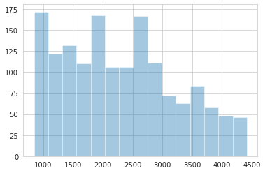

```python
sns.distplot(returns.count(1), kde=False);
```

```python
with pd.HDFStore(results_path / 'autoencoder.h5') as store:
    store.put('close', close)
    store.put('volume', volume)
    store.put('returns', returns)
    store.put('metadata', metadata)
```

## Factor Engineering

```python
MONTH = 21
```

### Price Trend

#### Short-Term Reversal

1-month cumulative return

```python
dates[:5]
```

```
DatetimeIndex(['1990-01-12', '1990-01-19', '1990-01-26', '1990-02-02',
               '1990-02-09'],
              dtype='datetime64[ns]', name='date', freq='W-FRI')
```

```python
mom1m = close.pct_change(periods=MONTH).resample('W-FRI').last().stack().to_frame('mom1m')
mom1m.info()
```

```
<class 'pandas.core.frame.DataFrame'>
MultiIndex: 3580621 entries, (Timestamp('1990-02-02 00:00:00', freq='W-FRI'), 'AA') to (Timestamp('2020-01-03 00:00:00', freq='W-FRI'), 'ZYXI')
Data columns (total 1 columns):
 #   Column  Dtype
---  ------  -----
 0   mom1m   float64
dtypes: float64(1)
memory usage: 41.2+ MB
```

```python
mom1m.squeeze().to_hdf(results_path / 'autoencoder.h5', 'factor/mom1m')
```

#### Stock Momentum

11-month cumulative returns ending 1-month before month end

```python
mom12m = (close
            .pct_change(periods=11 * MONTH)
            .shift(MONTH)
            .resample('W-FRI')
            .last()
            .stack()
            .to_frame('mom12m'))
```

```python
mom12m.info(null_counts=True)
```

```
<class 'pandas.core.frame.DataFrame'>
MultiIndex: 3375489 entries, (Timestamp('1991-01-04 00:00:00', freq='W-FRI'), 'AA') to (Timestamp('2020-01-03 00:00:00', freq='W-FRI'), 'ZYXI')
Data columns (total 1 columns):
 #   Column  Non-Null Count    Dtype
---  ------  --------------    -----
 0   mom12m  3375489 non-null  float64
dtypes: float64(1)
memory usage: 38.8+ MB
```

```python
mom12m.to_hdf(results_path / 'autoencoder.h5', 'factor/mom12m')
```

#### Momentum Change

Cumulative return from months t-6 to t-1 minus months t-12 to t-7.

```python
chmom = (close
         .pct_change(periods=6 * MONTH)
         .sub(close.pct_change(periods=6 * MONTH).shift(6 * MONTH))
         .resample('W-FRI')
         .last()
         .stack()
         .to_frame('chmom'))
```

```python
chmom.info(null_counts=True)
```

```
<class 'pandas.core.frame.DataFrame'>
MultiIndex: 3375489 entries, (Timestamp('1991-01-04 00:00:00', freq='W-FRI'), 'AA') to (Timestamp('2020-01-03 00:00:00', freq='W-FRI'), 'ZYXI')
Data columns (total 1 columns):
 #   Column  Non-Null Count    Dtype
---  ------  --------------    -----
 0   chmom   3375489 non-null  float64
dtypes: float64(1)
memory usage: 38.8+ MB
```

```python
chmom.to_hdf(results_path / 'autoencoder.h5', 'factor/chmom')
```

#### Industry Momentum

Equal-weighted avg. industry 12-month returns

```python
indmom = (close.pct_change(12*MONTH)
          .resample('W-FRI')
          .last()
          .stack()
          .to_frame('close')
          .join(metadata[['sector']]).groupby(['date', 'sector'])
          .close.mean()
          .to_frame('indmom')
          .reset_index())
```

```python
indmom.info(null_counts=True)
```

```
<class 'pandas.core.frame.DataFrame'>
RangeIndex: 18495 entries, 0 to 18494
Data columns (total 3 columns):
 #   Column  Non-Null Count  Dtype
---  ------  --------------  -----
 0   date    18495 non-null  datetime64[ns]
 1   sector  18495 non-null  object
 2   indmom  18495 non-null  float64
dtypes: datetime64[ns](1), float64(1), object(1)
memory usage: 433.6+ KB
```

```python
indmom = (returns
          .stack()
          .to_frame('ret')
          .join(metadata[['sector']])
          .reset_index()
          .merge(indmom)
          .set_index(['date', 'ticker'])
          .loc[:, ['indmom']])
```

```python
indmom.info(null_counts=True)
```

```
<class 'pandas.core.frame.DataFrame'>
MultiIndex: 3551199 entries, (Timestamp('1991-01-04 00:00:00'), 'AA') to (Timestamp('2020-01-03 00:00:00'), 'ZTR')
Data columns (total 1 columns):
 #   Column  Non-Null Count    Dtype
---  ------  --------------    -----
 0   indmom  3551199 non-null  float64
dtypes: float64(1)
memory usage: 40.8+ MB
```

```python
indmom.to_hdf(results_path / 'autoencoder.h5', 'factor/indmom')
```

#### Recent Max Return

Max daily returns from calendar month t-1

```python
maxret = (close
           .pct_change(periods=MONTH)
           .rolling(21)
           .max()
           .resample('W-FRI')
           .last()
           .stack()
           .to_frame('maxret'))
```

```python
maxret.info(null_counts=True)
```

```
<class 'pandas.core.frame.DataFrame'>
MultiIndex: 3562402 entries, (Timestamp('1990-03-02 00:00:00', freq='W-FRI'), 'AA') to (Timestamp('2020-01-03 00:00:00', freq='W-FRI'), 'ZYXI')
Data columns (total 1 columns):
 #   Column  Non-Null Count    Dtype
---  ------  --------------    -----
 0   maxret  3562402 non-null  float64
dtypes: float64(1)
memory usage: 41.0+ MB
```

```python
maxret.to_hdf(results_path / 'autoencoder.h5', 'factor/maxret')
```

#### Long-Term Reversal

Cumulative returns months t-36 to t-13.

```python
mom36m = (close
           .pct_change(periods=24*MONTH)
           .shift(12*MONTH)
           .resample('W-FRI')
           .last()
           .stack()
           .to_frame('mom36m'))
```

```python
mom36m.info(null_counts=True)
```

```
<class 'pandas.core.frame.DataFrame'>
MultiIndex: 2967391 entries, (Timestamp('1993-01-01 00:00:00', freq='W-FRI'), 'AA') to (Timestamp('2020-01-03 00:00:00', freq='W-FRI'), 'ZYXI')
Data columns (total 1 columns):
 #   Column  Non-Null Count    Dtype
---  ------  --------------    -----
 0   mom36m  2967391 non-null  float64
dtypes: float64(1)
memory usage: 34.2+ MB
```

```python
mom36m.to_hdf(results_path / 'autoencoder.h5', 'factor/mom36m')
```

### Liquidity Metrics

#### Turnover

Avg. monthly trading volume for most recent three months scaled by number of shares; we are using the most recent no of shares from yahoo finance

```python
turn = (volume
        .rolling(3*MONTH)
        .mean()
        .resample('W-FRI')
        .last()
        .div(metadata.sharesoutstanding)
        .stack('ticker')
        .to_frame('turn'))
```

```python
turn.info(null_counts=True)
```

```
<class 'pandas.core.frame.DataFrame'>
MultiIndex: 3506569 entries, (Timestamp('1990-03-30 00:00:00', freq='W-FRI'), 'AA') to (Timestamp('2020-01-03 00:00:00', freq='W-FRI'), 'ZYXI')
Data columns (total 1 columns):
 #   Column  Non-Null Count    Dtype
---  ------  --------------    -----
 0   turn    3506569 non-null  float64
dtypes: float64(1)
memory usage: 40.3+ MB
```

```python
turn.to_hdf(results_path / 'autoencoder.h5', 'factor/turn')
```

#### Turnover Volatility

Monthly std dev of daily share turnover

```python
turn_std = (prices
            .volume
            .unstack('ticker')
            .div(metadata.sharesoutstanding)
            .rolling(MONTH)
            .std()
            .resample('W-FRI')
            .last()
            .stack('ticker')
            .to_frame('turn_std'))
```

```python
turn_std.to_hdf(results_path / 'autoencoder.h5', 'factor/turn_std')
```

#### Log Market Equity

Natural log of market cap at end of month t-1

```python
last_price = close.ffill()
factor = close.div(last_price.iloc[-1])
mvel = np.log1p(factor.mul(metadata.marketcap).resample('W-FRI').last()).stack().to_frame('mvel')
```

```python
mvel.info(null_counts=True)
```

```
<class 'pandas.core.frame.DataFrame'>
MultiIndex: 3597636 entries, (Timestamp('1990-01-05 00:00:00', freq='W-FRI'), 'AA') to (Timestamp('2020-01-03 00:00:00', freq='W-FRI'), 'ZYXI')
Data columns (total 1 columns):
 #   Column  Non-Null Count    Dtype
---  ------  --------------    -----
 0   mvel    3597636 non-null  float64
dtypes: float64(1)
memory usage: 41.4+ MB
```

```python
mvel.to_hdf(results_path / 'autoencoder.h5', 'factor/mvel')
```

#### Dollar Volume

Natural log of trading volume time price per share from month t-2

```python
dv = close.mul(volume)
```

```python
dolvol = (np.log1p(dv.rolling(21)
                  .mean()
                  .shift(21)
                  .resample('W-FRI')
                  .last())
          .stack()
          .to_frame('dolvol'))
```

```python
dolvol.to_hdf(results_path / 'autoencoder.h5', 'factor/dolvol')
```

#### Amihud Illiquidity

Average of daily (absolute return / dollar volume)

```python
ill = (close.pct_change().abs()
       .div(dv)
       .rolling(21)
       .mean()
       .resample('W-FRI').last()
       .stack()
       .to_frame('ill'))
```

```python
ill.info(null_counts=True)
```

```
<class 'pandas.core.frame.DataFrame'>
MultiIndex: 3210773 entries, (Timestamp('1990-02-02 00:00:00', freq='W-FRI'), 'AA') to (Timestamp('2020-01-03 00:00:00', freq='W-FRI'), 'ZYXI')
Data columns (total 1 columns):
 #   Column  Non-Null Count    Dtype
---  ------  --------------    -----
 0   ill     3210773 non-null  float64
dtypes: float64(1)
memory usage: 36.9+ MB
```

```python
ill.to_hdf(results_path / 'autoencoder.h5', 'factor/ill')
```

### Risk Measures

#### Return Volatility

Standard dev of daily returns from month t-1.

```python
retvol = (close.pct_change()
          .rolling(21)
          .std()
          .resample('W-FRI')
          .last()
          .stack()
          .to_frame('retvol'))
```

```python
retvol.info(null_counts=True)
```

```
<class 'pandas.core.frame.DataFrame'>
MultiIndex: 3580621 entries, (Timestamp('1990-02-02 00:00:00', freq='W-FRI'), 'AA') to (Timestamp('2020-01-03 00:00:00', freq='W-FRI'), 'ZYXI')
Data columns (total 1 columns):
 #   Column  Non-Null Count    Dtype
---  ------  --------------    -----
 0   retvol  3580621 non-null  float64
dtypes: float64(1)
memory usage: 41.2+ MB
```

```python
retvol.to_hdf(results_path / 'autoencoder.h5', 'factor/retvol')
```

#### Market Beta

Estimated market beta from weekly returns and equal weighted market returns for 3 years ending month t-1 with at least 52 weeks of returns.

```python
index = close.resample('W-FRI').last().pct_change().mean(1).to_frame('x')
```

```python
def get_market_beta(y, x=index):
    df = x.join(y.to_frame('y')).dropna()
    model = RollingOLS(endog=df.y,
                       exog=sm.add_constant(df[['x']]),
                      window=3*52)

    return model.fit(params_only=True).params['x']
```

```python
beta = (returns.dropna(thresh=3*52, axis=1)
        .apply(get_market_beta).stack().to_frame('beta'))
```

```python
beta.info(null_counts=True)
```

```
<class 'pandas.core.frame.DataFrame'>
MultiIndex: 2969406 entries, (Timestamp('1993-01-01 00:00:00', freq='W-FRI'), 'AA') to (Timestamp('2020-01-03 00:00:00', freq='W-FRI'), 'ZYXI')
Data columns (total 1 columns):
 #   Column  Non-Null Count    Dtype
---  ------  --------------    -----
 0   beta    2969406 non-null  float64
dtypes: float64(1)
memory usage: 34.2+ MB
```

```python
beta.to_hdf(results_path / 'autoencoder.h5', 'factor/beta')
```

#### Beta Squared

Market beta squared

```python
betasq = beta.beta.pow(2).to_frame('betasq')
```

```python
betasq.info(null_counts=True)
```

```
<class 'pandas.core.frame.DataFrame'>
MultiIndex: 2969406 entries, (Timestamp('1993-01-01 00:00:00', freq='W-FRI'), 'AA') to (Timestamp('2020-01-03 00:00:00', freq='W-FRI'), 'ZYXI')
Data columns (total 1 columns):
 #   Column  Non-Null Count    Dtype
---  ------  --------------    -----
 0   betasq  2969406 non-null  float64
dtypes: float64(1)
memory usage: 34.2+ MB
```

```python
betasq.to_hdf(results_path / 'autoencoder.h5', 'factor/betasq')
```

#### Idiosyncratic return volatility

Standard dev of a regression of residuals of weekly returns on the returns of an equal weighted market index returns for the prior three years.

This takes a while!

```python
def get_ols_residuals(y, x=index):
    df = x.join(y.to_frame('y')).dropna()
    model = sm.OLS(endog=df.y, exog=sm.add_constant(df[['x']]))
    result = model.fit()
    return result.resid.std()
```

```python
idiovol = (returns.apply(lambda x: x.rolling(3 * 52)
                         .apply(get_ols_residuals)))
```

```python
idiovol = idiovol.stack().to_frame('idiovol')
```

```python
idiovol.info(null_counts=True)
```

```
<class 'pandas.core.frame.DataFrame'>
MultiIndex: 2969406 entries, (Timestamp('1993-01-01 00:00:00', freq='W-FRI'), 'AA') to (Timestamp('2020-01-03 00:00:00', freq='W-FRI'), 'ZYXI')
Data columns (total 1 columns):
 #   Column   Non-Null Count    Dtype
---  ------   --------------    -----
 0   idiovol  2969406 non-null  float64
dtypes: float64(1)
memory usage: 34.2+ MB
```

```python
idiovol.to_hdf(results_path / 'autoencoder.h5', 'factor/idiovol')
```